# Assignment 15: Writing a function - Conditional Statement

*How to do it?*:

- Open the Rmarkdown file of this assignment (link) in Rstudio.
- Right under each **question**, insert a code chunk (you can use the hotkey `Ctrl + Alt + I` to add a code chunk) and code the solution for the question.
- `Knit` the rmarkdown file (hotkey: `Ctrl + Alt + K`) to export an html.
- Publish the html file to your Githiub Page.

*Submission*: Submit the link on Github of the assignment to Canvas

#### NOTICE: Question 7, 8 and 9 are optional.

1. Write a function to calculate the age of a person. Give an example to test your function.
- Input: a number, x, (year born)
- Output: Print out “You are r age”. Where r is the age of the person, i.e. 2020 - x.

Hint: [Similar Function](https://bryantstats.github.io/math421/gganimate/17_writing_functions.html#42)

```r
calculate_age <- function(year_born) {
  current_date <- Sys.Date()
  current_year <- as.numeric(format(current_date, '%Y'))
  age <- current_year - year_born

  cat('You are', age, 'years old.')
}

example_year <- 2001

calculate_age(year_born = example_year)
```

```
## You are 22 years old.
```

2. Write the following function. Give an example to test your function.
- Input: a number
- Output: print out: “You input an even number!” if the number is event, or “You input an odd number!” otherwise.

Hint: [Similar Function](https://bryantstats.github.io/math421/gganimate/17_writing_functions.html#46)

```r
even_or_odd <- function(number) {
  if (number %% 2 == 0){
    print("You input an even number!")
  }
  else {
    print("You input an odd number")
  }
}

odd <- 13

even <- 46

even_or_odd(odd)
```

```
## [1] "You input an odd number"
```

```r
even_or_odd(even)
```

```
## [1] "You input an even number!"
```

3. Write the following function. Give an example to test your function.
- Input: a numeric vector
- Output:
  - if the input vector has missing values: return the input vector with missing values replaced by mean
  - if the input vector has no missing value: return the same input vector

Hint: [Similar Function](https://bryantstats.github.io/math421/gganimate/17_writing_functions.html#50)

```r
library(zoo)

fill_missing <- function(vector) {
  mean_val <- mean(vector, na.rm = TRUE)
  if(any(is.na(vector))){
    new_vec <- na.fill(vector, fill = mean_val)
    return(new_vec)
  }
  else {
    return(vector)
  }
}

example_vec <- c(1, NA, 5, 7, 10, NA)
new_example_vec <- fill_missing(example_vec)

print(new_example_vec)
```

```
## [1]  1.00  5.75  5.00  7.00 10.00  5.75
```

4. Write the following function. Give an example to test your function.
- Input: a vector x
- Output: The vector x where the missing values replaced by the mean (if x is numeric) or the mode (if x is non-numeric). If x does not have missing value, return the same vector x.

Hint: Use If-statement to combine the function in Question 3 and [this function](https://bryantstats.github.io/math421/gganimate/17_writing_functions.html#49)

```r
fill_missing2 <- function(vector) {
  if (is.numeric(vector)){
    mean_val <- mean(vector, na.rm = TRUE)
    if(any(is.na(vector))){
      new_vec <- na.fill(vector, fill = mean_val)
      return(new_vec)
    }
    else {
      return(vector)
    }
  }
  else {
    mode_val <- names(sort(-table(vector)))[1]
    if (any(is.na(vector))){
      new_vec <- na.fill(vector, fill = mode_val)
      return(new_vec)
    }
    else {
      return(vector)
    }
  }
}

example_vec <- c(1, NA, 5, 7, 10, NA)
new_example_vec <- fill_missing2(example_vec)

print(new_example_vec)
```

```
## [1]  1.00  5.75  5.00  7.00 10.00  5.75
```

```r
non_num_example_vec <- c('1', NA, '5', '7', '10', NA, '10')
new_non_num_example <- fill_missing2(non_num_example_vec)

print(new_non_num_example)
```

```
## [1] "1"  "10" "5"  "7"  "10" "10" "10"
```

5. Write the following function. Give examples to test your function.
- Input: A data frame of two variables x and y
- Output:
  - A boxplot of x by y if x is numeric and y is non-numeric
  - A boxplot of y by x if y is numeric and x is non-numeric
  - print out ‘This function cannot visualize your data’ otherwise

Hint:

- [Similar Function](https://bryantstats.github.io/math421/gganimate/17_writing_functions.html#53)
- You can refer to this slide to plot a boxplot: https://bryantstats.github.io/math421/slides/6_viz.html#36

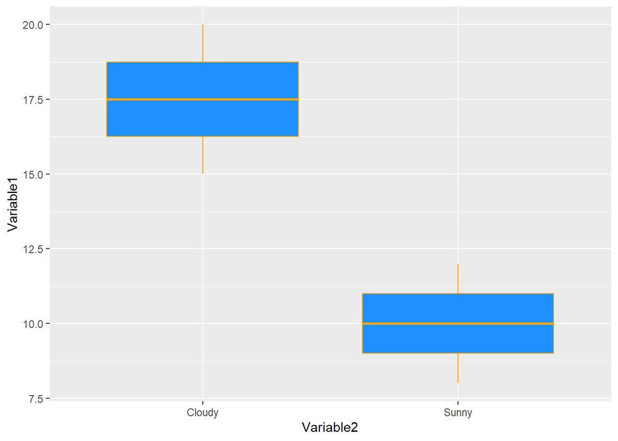

```r
boxplot_viz <- function(df) {
  library(ggplot2)
  if (is.numeric(df[[1]]) & !is.numeric(df[[2]])) {
    ggplot(df, aes(x = as.factor(df[[2]]), y = df[[1]])) +
      geom_boxplot(fill = 'dodgerblue', color = 'orange') +
      labs(x = names(df)[2], y = names(df)[1])
  } else if (is.numeric(df[[2]]) & !is.numeric(df[[1]])) {
    ggplot(df, aes(x = as.factor(df[[1]]), y = df[[2]])) +
      geom_boxplot(fill = 'dodgerblue', color = 'orange') +
      labs(x = names(df)[1], y = names(df)[2])
  }
  else {
    print('This function cannot visualize your data.')
  }
}

example_df <- data.frame(
  Variable1 = c(10, 15, 8, 20, 12),
  Variable2 = c("Sunny", "Cloudy", "Sunny", "Cloudy", "Sunny")
)

example_df$Variable2 <- as.factor(example_df$Variable2)

boxplot_viz(example_df)
```

6. Combine the function in Question 5 and the function in this example ([Link](https://bryantstats.github.io/math421/gganimate/17_writing_functions.html#53)) to have a function that can plot all possible cases (2 categorical, 2 numeric, 1 numeric and 1 categorical).

```r
#Chat GPT helped to resolve some issues with final condition (two categorical)
boxplot_viz2 <- function(df) {
  library(dplyr)
  library(ggplot2)
  if (is.numeric(df[[1]]) & !is.numeric(df[[2]])) {
    df %>%
      ggplot(aes(x = !!sym(names(df)[2]), y = !!sym(names(df)[1]))) +
      geom_boxplot(fill = 'dodgerblue', color = 'orange') +
      labs(x = names(df)[2], y = names(df)[1])
  } else if (is.numeric(df[[2]]) & !is.numeric(df[[1]])) {
    df %>%
      ggplot(aes(x = !!sym(names(df)[1]), y = !!sym(names(df)[2]))) +
      geom_boxplot(fill = 'dodgerblue', color = 'orange') +
      labs(x = names(df)[1], y = names(df)[2])
  } else if (is.numeric(df[[2]]) & is.numeric(df[[1]])) {
    df %>%
      ggplot(aes(x = !!sym(names(df)[1]), y = !!sym(names(df)[2]))) +
      geom_point() +
      labs(x = names(df)[1], y = names(df)[2])
  } else if (!is.numeric(df[[2]]) & !is.numeric(df[[1]])) {
    df %>%
      group_by(!!sym(names(df)[1]), !!sym(names(df)[2])) %>%
      count() %>%
      ggplot(aes(x = !!sym(names(df)[1]), y = n, fill = !!sym(names(df)[2]))) +
      geom_bar(stat = 'identity') +
      labs(x = names(df)[1], y = 'Count', fill = names(df)[2]) +
      scale_fill_discrete(drop = FALSE)
  }
  else {
    stop('Error: Dataframe not suitable for visualization.')
  }
}
```

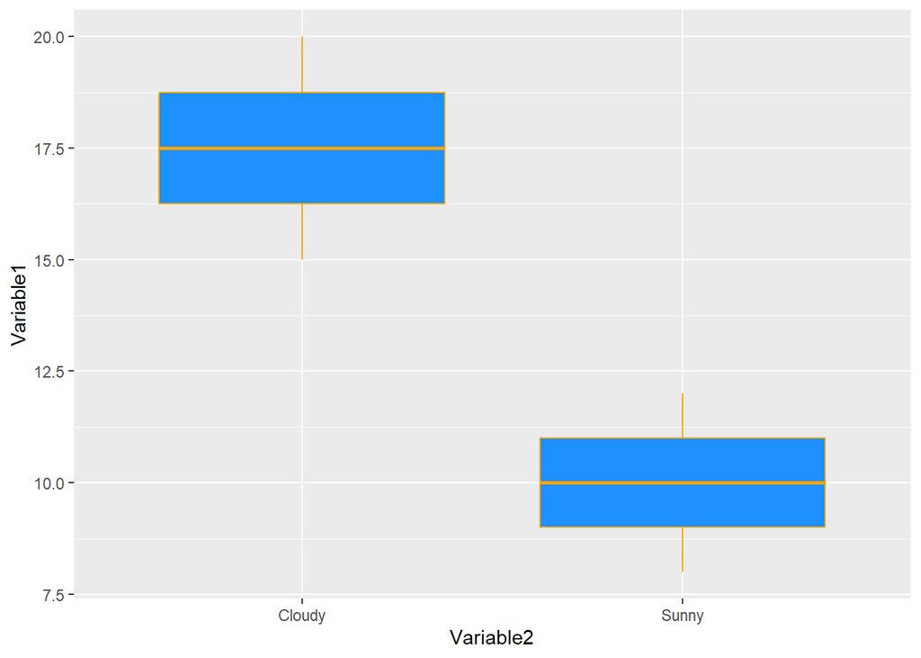

```r
example_df <- data.frame(
  Variable1 = c(10, 15, 8, 20, 12),
  Variable2 = c("Sunny", "Cloudy", "Sunny", "Cloudy", "Sunny")
)

example_df$Variable2 <- as.factor(example_df$Variable2)

boxplot_viz2(example_df)
```

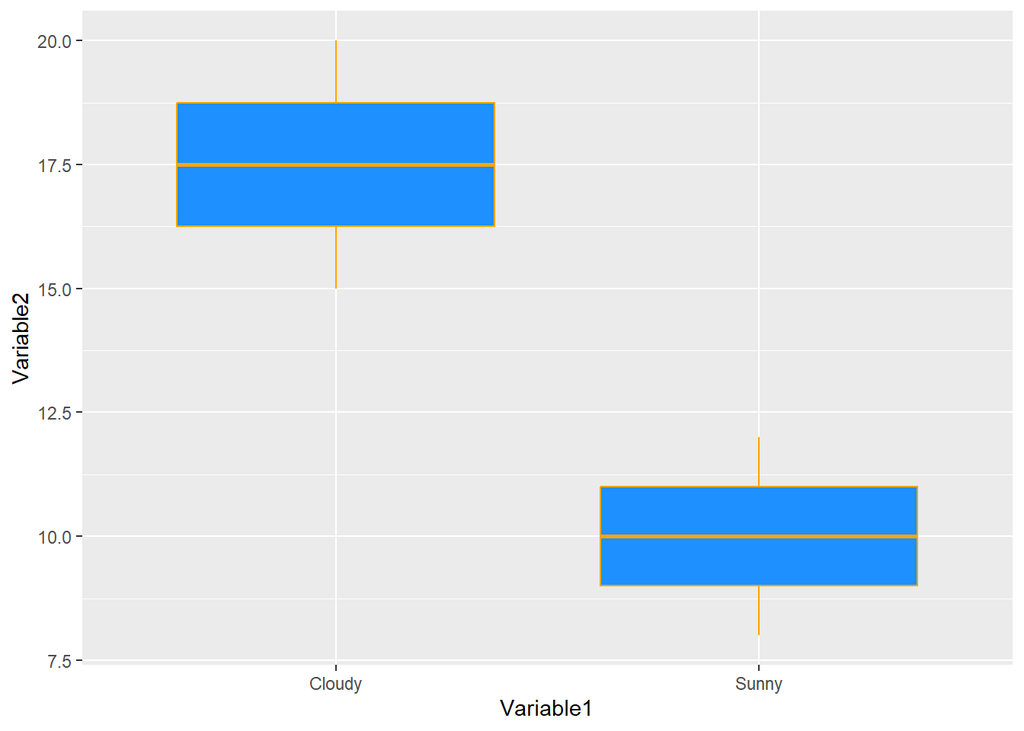

```r
example_df <- data.frame(
  Variable1 = c("Sunny", "Cloudy", "Sunny", "Cloudy", "Sunny"),
  Variable2 = c(10, 15, 8, 20, 12)
)

example_df$Variable1 <- as.factor(example_df$Variable1)

boxplot_viz2(example_df)
```

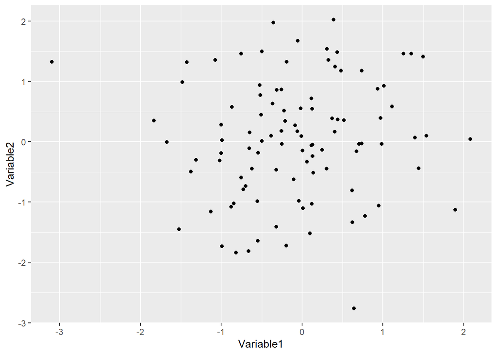

```r
example_df <- data.frame(
  Variable1 = rnorm(100),
  Variable2 = rnorm(100)
)

boxplot_viz2(example_df)
```

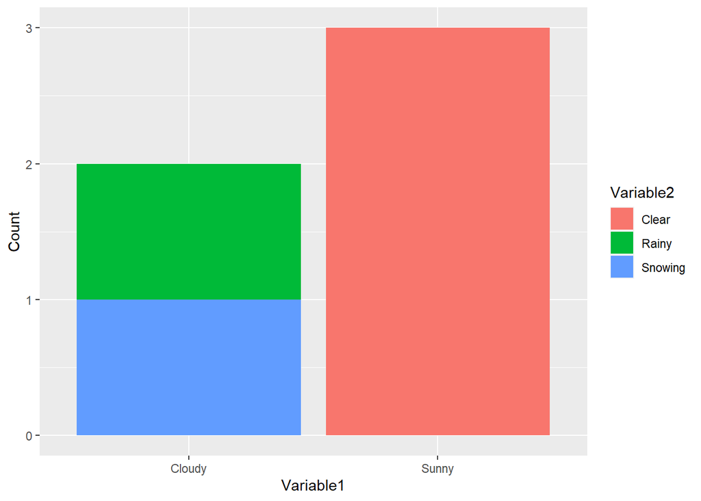

```r
example_df <- data.frame(
  Variable1 = c("Sunny", "Cloudy", "Sunny", "Cloudy", "Sunny"),
  Variable2 = c("Clear", "Rainy", "Clear", "Snowing", "Clear")
)

example_df$Variable1 <- as.factor(example_df$Variable1)
example_df$Variable2 <- as.factor(example_df$Variable2)

boxplot_viz2(example_df)
```

#### NOTICE: Question 7, 8 and 9 are optional.

7. Write the following function. Give examples to test your function.
- Input:
  - input_data: a clean data frame with a variable name `target`. The `target` variable is also binary.
  - train_percent: a number presenting a proportion of training data. The default train_percent is .8
- Output: the accuracy of the decision model `rpart` where the training data is train_percent.

```r
model_func1 <- function(input_data, train_percent)
{
library(caret)
set.seed(27182)
splitIndex <- createDataPartition(input_data$target, p = train_percent,
                                  list = FALSE)
df_train <- input_data[ splitIndex,]
df_test <- input_data[-splitIndex,]
model <- train(target~., data=df_train,
                        method = "rpart")
pred <- predict(model, df_test)
cm <- confusionMatrix(data = pred, reference = df_test$target)
cm$overall[1]
}
```

```r
library(tidyverse)

df = read_csv("titanic.csv")

names(df)[8] <- 'target'

df$PassengerId =  NULL
df$Ticket =  NULL
df$Name = NULL
df$Cabin = NULL

df$target <- factor(df$target)
df$Pclass = factor(df$Pclass)
df$Sex <- factor(df$Sex)
df$Embarked <- factor(df$Embarked)

df$Age[is.na(df$Age)] = mean(df$Age, na.rm = TRUE)
df = drop_na(df)

model_func1(input_data = df, train_percent = .7)
```

```
##  Accuracy
## 0.8068182
```

8. Write the following function. Give examples to test your function.
- Input:
  - input_data: a clean data frame with a variable name `target`. The `target` variable is also binary.
  - train_percent: a number presenting a proportion of training data. The default train_percent is .8
- Output: the plot of variable important by random forest trained by caret.

```r
model_func2 <- function(input_data, train_percent)
{
library(caret)
set.seed(27182)
splitIndex <- createDataPartition(input_data$target, p = train_percent,
                                  list = FALSE)
df_train <- input_data[ splitIndex,]
df_test <- input_data[-splitIndex,]
rf_model <- train(target~., data=df_train,
                        method = "rf")

plot(varImp(rf_model))
}
```

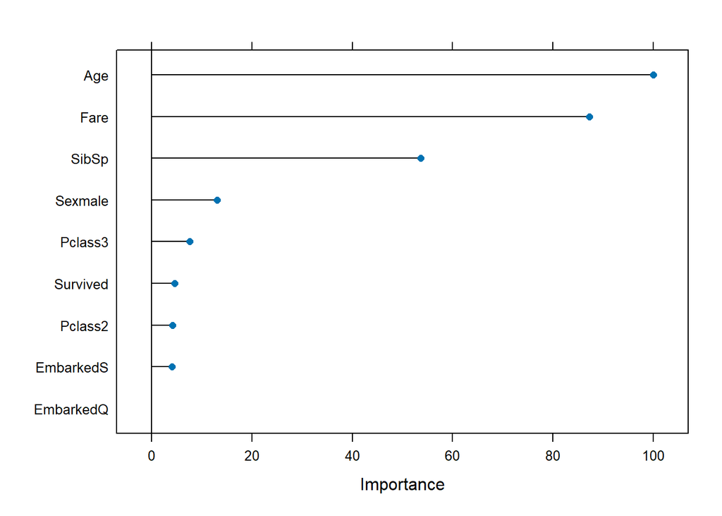

```r
df = read_csv("titanic.csv")

names(df)[8] <- 'target'

df$PassengerId =  NULL
df$Ticket =  NULL
df$Name = NULL
df$Cabin = NULL

df$target <- factor(df$target)
df$Pclass = factor(df$Pclass)
df$Sex <- factor(df$Sex)
df$Embarked <- factor(df$Embarked)

df$Age[is.na(df$Age)] = mean(df$Age, na.rm = TRUE)
df = drop_na(df)

model_func2(input_data = df, train_percent = .7)
```

9. Write the following function. Give examples to test your function.
- Input:
  - a data frame that has a text column
  - the name of the text column in the data
- Output: the word cloud plot of the text column

Sample codes

- [Word Cloud codes](https://bryantstats.github.io/math421/assignments/text_mining_sample_codes2.html#Total_Word_Cloud)
- [A similar function](https://bryantstats.github.io/math421/gganimate/17_writing_functions.html#10)

```r
word_cloud_func <- function(df, colName) {
  library(wordcloud)
  library(tidyr)
  library(tidytext)
  library(dplyr)
  library(stopwords)
  library(RColorBrewer)

  pal <- brewer.pal(8, "Dark2")

  df %>%
  unnest_tokens(input = colName, output = word) %>%
  anti_join(get_stopwords()) %>%
  count(word, sort = TRUE) %>%
  filter(nchar(word)>1) %>%
  with(wordcloud(word, n, random.order = FALSE, max.words = 50, colors=pal))
}
```

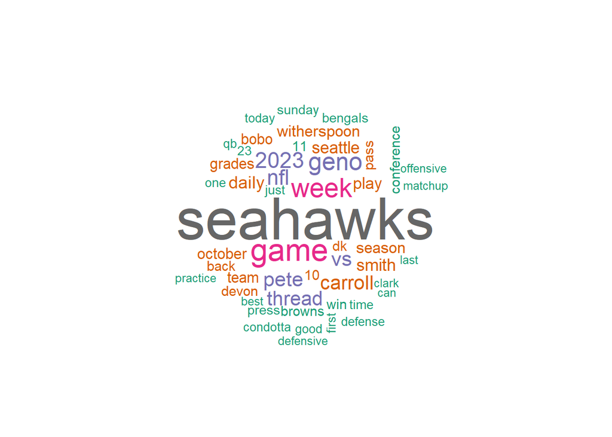

```r
library(tidyverse)
df <- read_csv('seahawks.csv')

word_cloud_func(df, 'title')
```